# PA1_template.Rmd

2022-07-02

## Loading and preprocessing the data

```r
library(hms)
library(dplyr)
library(ggplot2)
```

```r
library(hms)
library(dplyr)
library(ggplot2)
data <- read.csv('activity.csv')
data$interval <- as.character(data$interval)
for (i in 1:3){
  data$interval <- ifelse(nchar(data$interval) == i, paste(strrep('0', 4 - i), data$interval, sep = ''),
                          data$interval)
}
data$interval <- as_hms(as.POSIXct(data$interval, format = '%H%M'))
data$date <- as.POSIXct(data$date, format = '%Y-%m-%d')
```

## What is mean total number of steps taken per day?

#### Calculate the total number of steps taken per day

```r
data_per_day <- group_by(data, data$date)
steps_per_day <- summarise(data_per_day, total_steps = sum(steps, na.rm = TRUE))
steps_per_day
```

```
## # A tibble: 61 x 2
##    `data$date`         total_steps
##    <dttm>                    <int>
##  1 2012-10-01 00:00:00           0
##  2 2012-10-02 00:00:00         126
##  3 2012-10-03 00:00:00       11352
##  4 2012-10-04 00:00:00       12116
##  5 2012-10-05 00:00:00       13294
##  6 2012-10-06 00:00:00       15420
##  7 2012-10-07 00:00:00       11015
##  8 2012-10-08 00:00:00           0
##  9 2012-10-09 00:00:00       12811
## 10 2012-10-10 00:00:00        9900
## # ... with 51 more rows
```

#### Make a histogram of the total number of steps taken each day

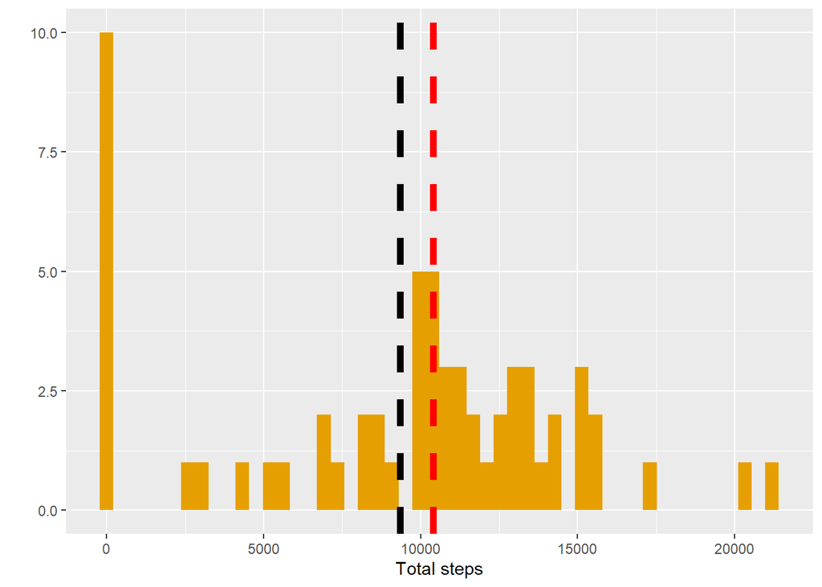

```r
ggplot(steps_per_day, aes(x = total_steps)) + geom_histogram(bins = 50, fill = '#E69F00') +
  geom_vline(aes(xintercept = mean(total_steps, na.rm = TRUE)), linetype = "dashed", size = 2) +
  geom_vline(aes(xintercept = median(total_steps, na.rm = TRUE)), linetype = "dashed", size = 2,
             color = 'red') + labs(x = 'Total steps', y = '')
```

#### Calculate and report the mean and median of the total number of steps taken per day

```r
mean(steps_per_day$total_steps)
```

```
## [1] 9354.23
```

```r
median(steps_per_day$total_steps)
```

```
## [1] 10395
```

## What is the average daily activity pattern?

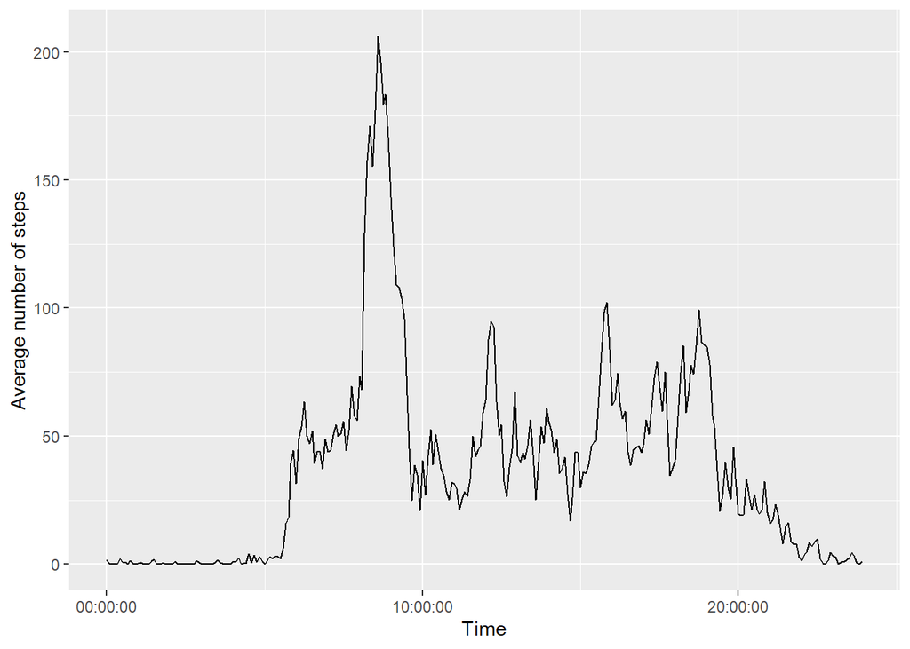

```r
data_per_interval <- group_by(data, data$interval)
steps_per_int <- summarise(data_per_interval, mean_steps = mean(steps, na.rm = TRUE))
ggplot(steps_per_int, aes(x = `data$interval`, y = mean_steps)) + geom_line() +
  labs(x = 'Time', y = 'Average number of steps')
```

#### Which 5-minute interval, on average across all the days in the dataset, contains the maximum number of steps?

```r
steps_per_int$`data$interval`[steps_per_int$mean_steps == max(steps_per_int$mean_steps)]
```

```
## 08:35:00
```

## Imputing missing values

#### Calculate and report the total number of missing values in the dataset

```r
sum(is.na(data))
```

```
## [1] 2304
```

#### Use the mean for that 5-minute interval for filling in all of the missing values in the dataset.

```r
data <- merge(data, steps_per_int, all.x=TRUE, by.x = 'interval', by.y = 'data$interval')
data$steps <- with(data, ifelse(is.na(steps) == TRUE, mean_steps, steps))
data <- subset(data, select = -mean_steps)
```

#### Make a histogram of the total number of steps taken each day and Calculate and report the mean and median total number of steps taken per day. Do these values differ from the estimates from the first part of the assignment? What is the impact of imputing missing data on the estimates of the total daily number of steps?

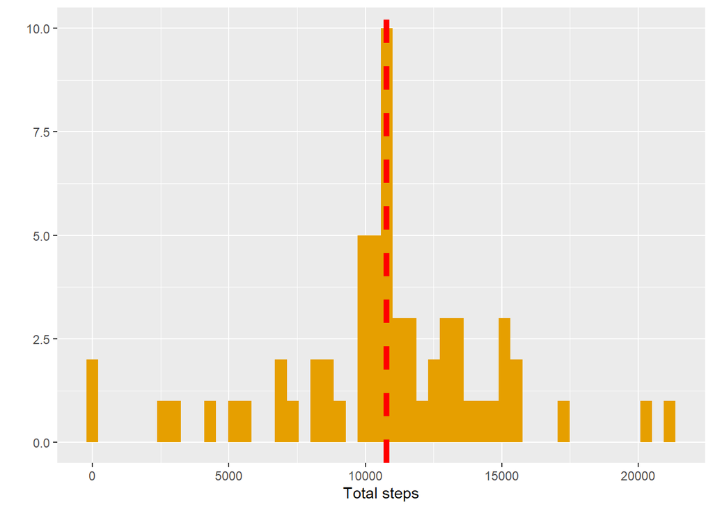

```r
data_per_day <- group_by(data, data$date)
steps_per_day2 <- summarise(data_per_day, total_steps = sum(steps))
ggplot(steps_per_day2, aes(x = total_steps)) + geom_histogram(bins = 50, fill = '#E69F00') +
  geom_vline(aes(xintercept = mean(total_steps)), linetype = "dashed", size = 2) +
  geom_vline(aes(xintercept = median(total_steps)), linetype = "dashed", size = 2,
             color = 'red') + labs(x = 'Total steps', y = '')
```

```r
mean(steps_per_day2$total_steps)
```

```
## [1] 10766.19
```

```r
median(steps_per_day2$total_steps)
```

```
## [1] 10766.19
```

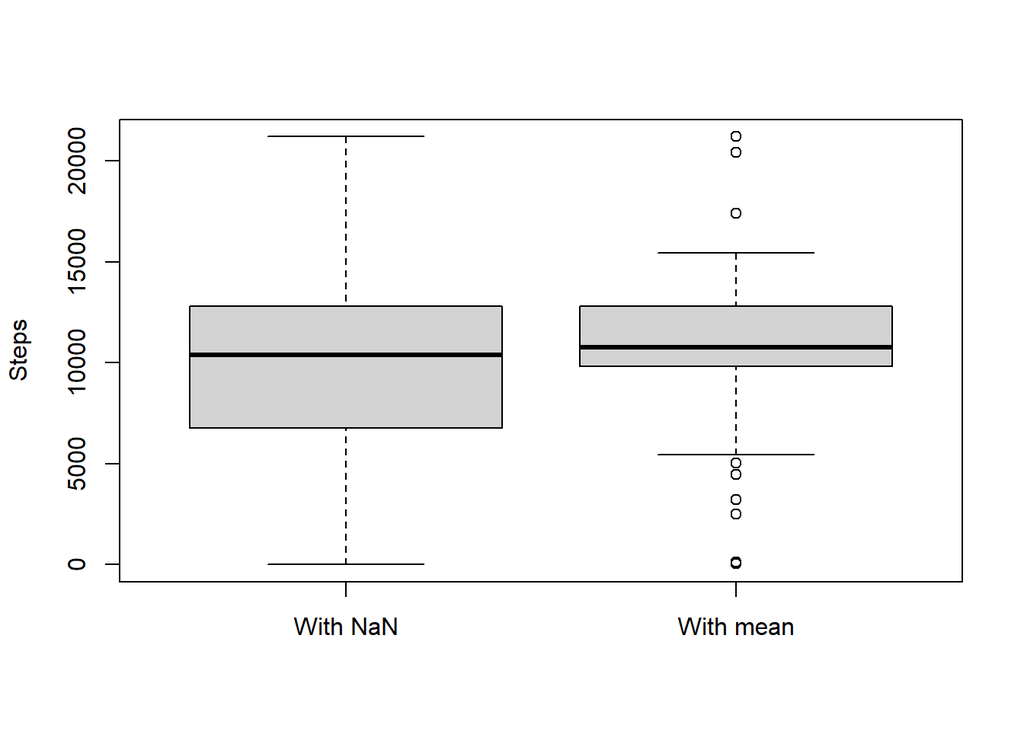

```r
boxplot(steps_per_day$total_steps, steps_per_day2$total_steps, names = c('With NaN', 'With mean'),
        ylab = 'Steps')
```

## Are there differences in activity patterns between weekdays and weekends?

#### Create a new factor variable in the dataset with two levels – “weekday” and “weekend” indicating whether a given date is a weekday or weekend day.

```r
data$day <- ifelse(weekdays(data$date, abbreviate = TRUE) %in% c('Сб', 'Вс'), 'Weekend', 'Weekday')
data_per_interval <- group_by(data, data$interval, data$day)
steps_per_int <- summarise(data_per_interval, mean_steps = mean(steps, na.rm = TRUE))
```

#### Make a panel plot containing a time series plot of the 5-minute interval (x-axis) and the average number of steps taken, averaged across all weekday days or weekend days (y-axis).

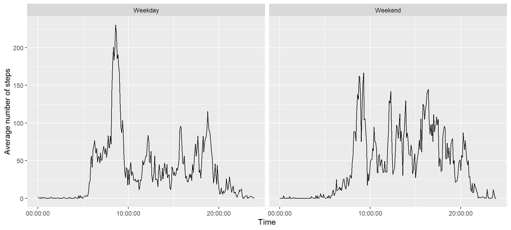

```r
ggplot(steps_per_int, aes(`data$interval`, mean_steps)) + geom_line() + facet_wrap(.~`data$day`) +
  labs(x = 'Time', y = 'Average number of steps')
```